# Term Deposit Sale Project

### Multivariate Analysis (8 Marks)

Before we proceed, let's perform necessary data transformations for multivariate analysis:

1. Consider absolute values for 'balance' to remove the negative values.
2. Replace unknowns from 'contact' with 'cellular' and 'telephone' proportionately.
3. Try to reduce unknowns from 'job' by inferring from education and age.
4. Try to reduce unknowns from 'education', by inferring from age and job.

```python
# Create a copy for data transformations.
data_df = bank_df.copy(deep=True)

# Get absolute values for balance
data_df['balance'] = data_df.balance.abs()

# Replace unknown values of 'contact' variable proportionately with cellular and telephone
vc = data_df.contact.value_counts()
cell_percent =  vc['cellular'] / (vc['cellular'] + vc['telephone'])
cell_count = int(round(vc['unknown'] * cell_percent))

contact_values = data_df.contact.values.tolist()
for idx in range(len(contact_values)):
    if contact_values[idx] == 'unknown':
        if cell_count > 0:
            contact_values[idx] = 'cellular'
            cell_count -= 1
        else:
            contact_values[idx] = 'telephone'
data_df['contact'] = contact_values

print("Number of customers left with negative balance: ", data_df[data_df.balance < 0].shape[0])
print("Number of customers left with unknown contact type: ", data_df[data_df.contact == 'unknown'].shape[0])
```

```
Number of customers left with negative balance:  0
Number of customers left with unknown contact type:  0
```

#### Inferring unknown job values from education and age

```python
# Let's look at cross tabulation between job and education
pd.crosstab(data_df.education, data_df.job)
```

| job education | admin. | blue-collar | entrepreneur | housemaid | management | retired | self-employed | services | student | technician | unemployed | unknown |
| --- | --- | --- | --- | --- | --- | --- | --- | --- | --- | --- | --- | --- |
| primary | 209 | 3758 | 183 | 627 | 294 | 795 | 130 | 345 | 44 | 158 | 257 | 51 |
| secondary | 4219 | 5371 | 542 | 395 | 1121 | 984 | 577 | 3457 | 508 | 5229 | 728 | 71 |
| tertiary | 572 | 149 | 686 | 173 | 7801 | 366 | 833 | 202 | 223 | 1968 | 289 | 39 |
| unknown | 171 | 454 | 76 | 45 | 242 | 119 | 39 | 150 | 163 | 242 | 29 | 127 |

```python
# Based on above observations -

# let's replace unknown job values, for customers with primary or secondary education, with 'blue-collar'
data_df.loc[(data_df.job == 'unknown') &
           ((data_df.education=='primary') | (data_df.education=='secondary')), 'job'] = 'blue-collar'

# Let's replace unknown job values, for customers with tertiary education, with 'management'
data_df.loc[(data_df.job == 'unknown') & (data_df.education == 'tertiary'), 'job'] = 'management'

print("Number of customers left with unknown jobs: ", data_df[data_df.job == 'unknown'].shape[0])
```

```
Number of customers left with unknown jobs:  127
```

```python
# For customers left with unknown education values, let's try infering their job based on their ages.

# Let's look at the ages for different job categories.
job_age_df = data_df.groupby('job').age.min().to_frame().T
job_age_df = job_age_df.append(data_df.groupby('job').age.mean().to_frame().T, ignore_index=True)
job_age_df = job_age_df.append(data_df.groupby('job').age.max().to_frame().T, ignore_index=True)
job_age_df.index = ['min. age', 'avg. age', 'max. age']
job_age_df
```

| job | admin. | blue-collar | entrepreneur | housemaid | management | retired | self-employed | services | student | technician | unemployed | unknown |
| --- | --- | --- | --- | --- | --- | --- | --- | --- | --- | --- | --- | --- |
| min. age | 20.000000 | 20.000000 | 21.000000 | 22.000000 | 21.000000 | 24.000000 | 22.000000 | 20.00000 | 18.000000 | 21.000000 | 21.000000 | 25.000000 |
| avg. age | 39.289886 | 40.111731 | 42.190989 | 46.415323 | 40.476782 | 61.626767 | 40.484484 | 38.74025 | 26.542644 | 39.314598 | 40.961627 | 49.755906 |
| max. age | 75.000000 | 75.000000 | 84.000000 | 83.000000 | 81.000000 | 95.000000 | 76.000000 | 69.00000 | 48.000000 | 71.000000 | 66.000000 | 82.000000 |

```python
# Based on above observations -

# Let's replace unknown job values of customers above 60 years with 'retired'
data_df.loc[(data_df.job == 'unknown') & (data_df.age > 60), 'job'] = 'retired'

# Let's mark all customers, with unknown job values, between age 15 and 25 as students
data_df.loc[(data_df.job == 'unknown') & ((data_df.age > 15) & (data_df.age <= 25)), 'job'] = 'student'

# Based on distribution of age alone it's difficult to further infer job values.
# Let's mark the remaining customers (about 115) as unemployed for simplicity.
data_df.loc[data_df.job == 'unknown', 'job'] = 'unemployed'

print("Number of customers left with unknown jobs: ", data_df[data_df.job == 'unknown'].shape[0])
```

```
Number of customers left with unknown jobs:  0
```

#### Inferring unknown education values from job and age

Since we have eliminated unknowns from the job, we can use it to infer the unknowns from education

```python
# Let's look at the age distribution per education level
edu_age_df = data_df.groupby('education').age.min().to_frame().T
edu_age_df = edu_age_df.append(data_df.groupby('education').age.mean().to_frame().T, ignore_index=True)
edu_age_df = edu_age_df.append(data_df.groupby('education').age.max().to_frame().T, ignore_index=True)
edu_age_df.index = ['min. age', 'avg. age', 'max. age']
edu_age_df
```

| education | primary | secondary | tertiary | unknown |
| --- | --- | --- | --- | --- |
| min. age | 18.000000 | 18.00000 | 20.00000 | 18.000000 |
| avg. age | 45.865567 | 39.96427 | 39.59364 | 44.510501 |
| max. age | 95.000000 | 95.00000 | 89.00000 | 93.000000 |

As seen above, it's difficult to infer the education levels based on distribution of age. Let's find the most frequent education level in each job category. Then, replace the unknown value with education level that is most frequent in that customer's job category.

```python
# Get popular education levels per job category
freq_edu_per_job = data_df.groupby('job').apply(lambda x: x['education'].value_counts().index[0])
job_edu_dict = {x:y for (x,y) in zip(freq_edu_per_job.index, freq_edu_per_job.values)}
print("Popular education level per job:")
for job, edu in job_edu_dict.items():
    print("{0} \t: {1}".format(job, edu))
```

```
Popular education level per job:
admin. 	: secondary
blue-collar 	: secondary
entrepreneur 	: tertiary
housemaid 	: primary
management 	: tertiary
retired 	: secondary
self-employed 	: tertiary
services 	: secondary
student 	: secondary
technician 	: secondary
unemployed 	: secondary
```

```python
# Replace unknowns from education with corresponding popular education level for that job
data_df['education'] = data_df.apply(lambda x : job_edu_dict[x['job']] if x['education'] == 'unknown'
                                     else x['education'], axis=1)
print("Number of customers left with unknown education levels: ", data_df[data_df.education == 'unknown'].shape[0])
```

```
Number of customers left with unknown education levels:  0
```

#### Bi-variate analysis between the predictor variables and target column

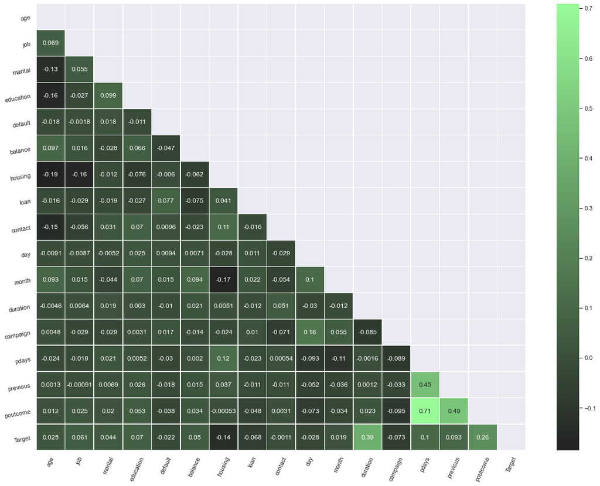

```python
# Let's convert categorical values to numerical, for correlation analysis
replaceStruct = {
    'job'       : {'blue-collar':1, 'management':2, 'technician':3, 'admin.':4, 'services':5, 'retired': 6,
                   'self-employed':7, 'entrepreneur':8, 'unemployed':9, 'housemaid':10, 'student':11},
    'marital'   : {'married':1, 'single':2, 'divorced':3},
    'education' : {'primary':1, 'secondary':2, 'tertiary':3},
    'default'   : {'yes': 1, 'no': 0},
    'housing'   : {'yes': 1, 'no': 0},
    'loan'      : {'yes': 1, 'no': 0},
    'contact'   : {'cellular': 1, 'telephone': 0},
    'month'     : {'jan':1, 'feb':2, 'mar':3, 'apr':4, 'may':5, 'jun':6, 'jul':7, 'aug':8, 'sep':9, 'oct':10,
                   'nov':11, 'dec':12},
    'poutcome'  : {'unknown': 1, 'failure': 2, 'other': 3, 'success': 4},
    'Target'    : {'yes': 1, 'no': 0}
}

# Get numerical values for categorical attributes
data_num = data_df.replace(replaceStruct)

# Let's visualize heatmap for the co-relation between attributes.
corr_df = data_num.corr()

# Create a mask to hide upper triangle of repeated values
upper_tri_mask = np.zeros_like(corr_df, dtype=np.bool)
upper_tri_mask[np.triu_indices_from(upper_tri_mask)] = True

# Draw the heatmap
plt.figure(figsize=(20,15))
pal = sns.dark_palette("palegreen", as_cmap=True)
pop_hmap = sns.heatmap(corr_df, mask=upper_tri_mask, annot=True, cmap=pal, linewidths=.5)
pop_hmap.set_xticklabels(pop_hmap.get_xticklabels(), rotation=65)
pop_hmap.set_yticklabels(pop_hmap.get_yticklabels(), rotation=10)
plt.show()
```

#### *Observations* :

- pdays and poutcome has strong positive relation. Based on pdays, lot of customers have not been contacted recently or ever at all and that corresponds to lot of unknown values from poutcome.
- Also, pdays and previous have good positive correlation and is fairly obvious from their definitions.
- Clearly, previous and poutcome has good positive correlation.
- Target (dependent attribute) does not have very strong correlation with most of the independent numerical attributes. It has good positive correlation with duration of time the customer was contacted previously.

```python
# Let's look at the average of numerical variables, for Target variable values yes and no
data_df.groupby('Target')[numerical_vars].mean()
```

| Target | age | balance | duration | campaign | pdays | previous |
| --- | --- | --- | --- | --- | --- | --- |
| no | 40.838986 | 1360.464130 | 221.182806 | 2.846350 | 36.421372 | 0.502154 |
| yes | 41.670070 | 1828.319342 | 537.294574 | 2.141047 | 68.702968 | 1.170354 |

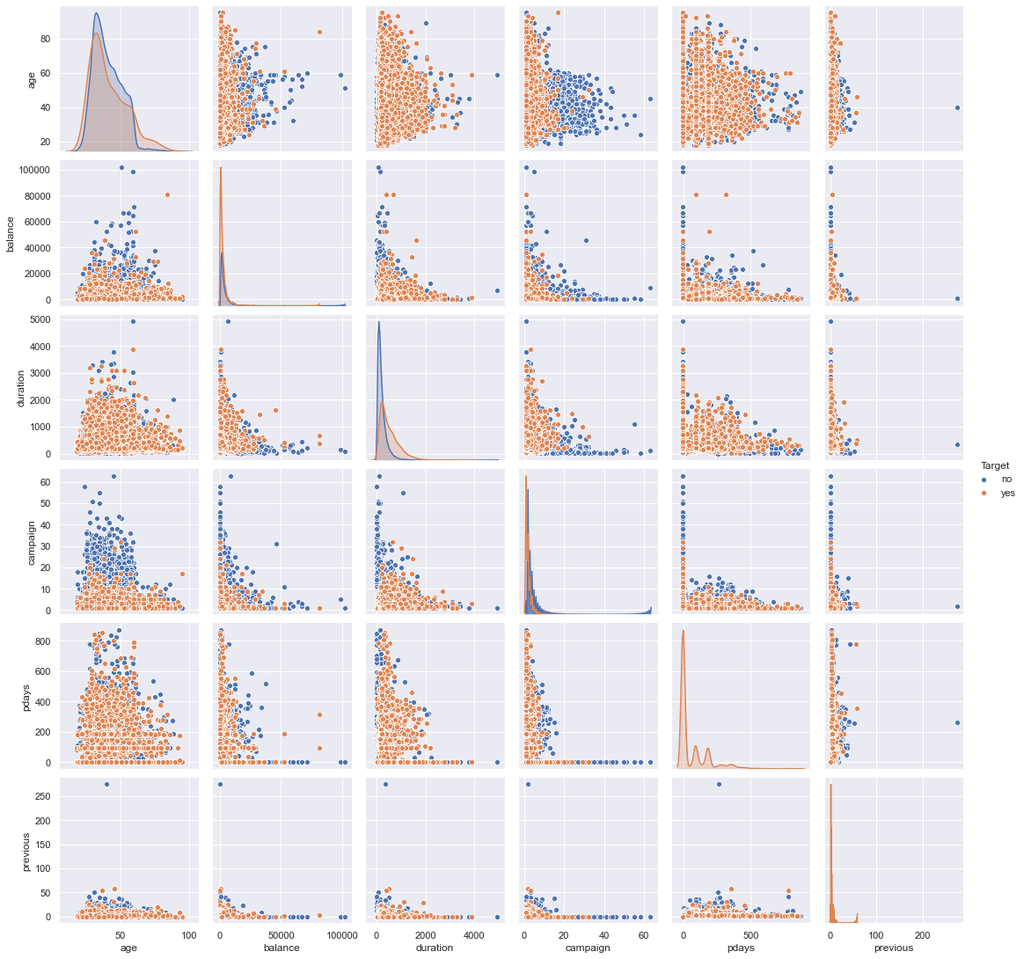

```python
# Let's look at the pair wise relation ship between numerical aatributes and the Target.
pairplot_cols = numerical_vars + ['Target']
sns.pairplot(data_df[pairplot_cols], hue='Target');
```

#### *Observations*:

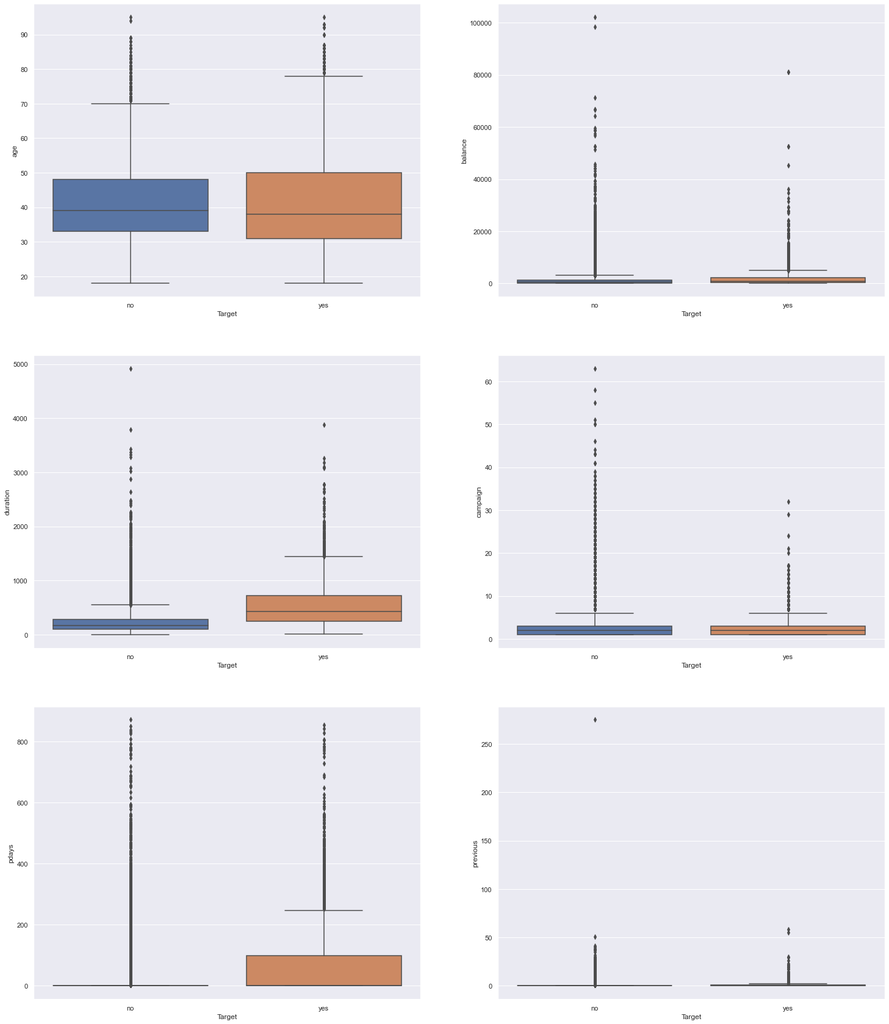

```python
# Let's look at the IQRs and distributions of numerical variables with respect to the Targe attribute

plt.figure(figsize=(25, 30))
plot_idx = 1
for var in numerical_vars:
    plt.subplot(3, 2, plot_idx)
    sns.boxplot(data=data_df, x='Target', y=var);
    plot_idx += 1
```

#### *Observations* :

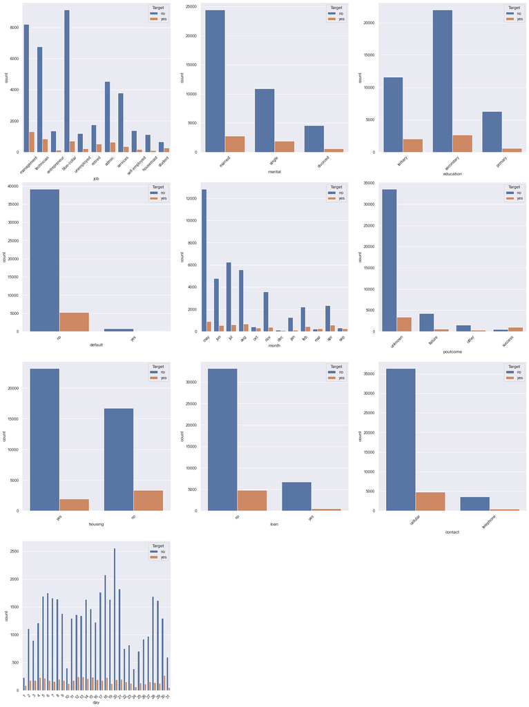

```python
# Let's look at the impact of categorical variables on customers opting for term deposit (target variable)
cat_variables.remove('Target')
plt.figure(figsize=(25, 35))
idx = 1
for idx in range(len(cat_variables)):
    plt.subplot(4, 3, idx+1)
    plot = sns.countplot(data_df[cat_variables[idx]], hue=data_df.Target);
    plot.set_xticklabels(plot.get_xticklabels(), rotation=45);
    idx += 1
```

#### *Observations* :

- Customers with management, technician and blue-collar jobs have opted for term deposit more than customers with other jobs.
- More married customers have opted for term deposit.
- More customers with secondary education have opted for term deposit.
- More customers with no credit in default have opted for term deposit.
- More customers who were contacted during the month of May, have opted for term deposit.
- More customers with no housing loan have opted for term deposit.
- More customers with no personal loan have opted for term deposit.
- More customers with cellular contact type have opted for term deposit.
- More customers who contacted during middle of the month, have opted for term deposit.

## Prepare Data for Analytics

### Ensure the attribute types are correct

```python
# Let's convert the object type attributes to categorical
for feature in data_df.columns: # Loop through all columns in the dataframe
    if data_df[feature].dtype == 'object': # Only apply for columns with categorical strings
        data_df[feature] = pd.Categorical(data_df[feature])# Replace strings with an integer

data_df['day'] = data_df['day'].astype('category')
data_df.info()
```

```
<class 'pandas.core.frame.DataFrame'>
RangeIndex: 45211 entries, 0 to 45210
Data columns (total 17 columns):
 #   Column     Non-Null Count  Dtype
---  ------     --------------  -----
 0   age        45211 non-null  int64
 1   job        45211 non-null  category
 2   marital    45211 non-null  category
 3   education  45211 non-null  category
 4   default    45211 non-null  category
 5   balance    45211 non-null  int64
 6   housing    45211 non-null  category
 7   loan       45211 non-null  category
 8   contact    45211 non-null  category
 9   day        45211 non-null  category
 10  month      45211 non-null  category
 11  duration   45211 non-null  int64
 12  campaign   45211 non-null  int64
 13  pdays      45211 non-null  int64
 14  previous   45211 non-null  int64
 15  poutcome   45211 non-null  category
 16  Target     45211 non-null  category
dtypes: category(11), int64(6)
memory usage: 2.5 MB
```

### Transform the data i.e. scale / normalize if required.

We have already fixed negative values from 'balance' attribute, replaced unknowns from 'job', 'education' and 'contact' attributes. Let's label encode and successively one-hot encode the categorical variables; and scale numerical attributes to handle outliers.

```python
# Label encode binary categories
replaceStruct = {
    'default'   : {'yes': 1, 'no': 0},
    'housing'   : {'yes': 1, 'no': 0},
    'loan'      : {'yes': 1, 'no': 0},
    'Target'    : {'yes': 1, 'no': 0},
}
data_le = data_df.replace(replaceStruct)

# Let's one-hot encode the remaining categorical values
oneHotEncodeCols = ['job', 'marital', 'education', 'month', 'poutcome', 'day','contact']
data_clean = pd.get_dummies(data_le, columns=oneHotEncodeCols, drop_first=True)

# Let's use robust scalar to scale numerical data with outliers
scaler = RobustScaler()
data_clean[numerical_vars] = scaler.fit_transform(data_clean[numerical_vars])
data_clean
```

|  | age | default | balance | housing | loan | duration | campaign | pdays | previous | Target | ... | day_23 | day_24 | day_25 | day_26 | day_27 | day_28 | day_29 | day_30 | day_31 | contact_telephone |
| --- | --- | --- | --- | --- | --- | --- | --- | --- | --- | --- | --- | --- | --- | --- | --- | --- | --- | --- | --- | --- | --- |
| 0 | 1.266667 | 0 | 1.276366 | 1 | 0 | 0.375000 | -0.5 | 0.0 | 0.0 | 0 | ... | 0 | 0 | 0 | 0 | 0 | 0 | 0 | 0 | 0 | 0 |
| 1 | 0.333333 | 0 | -0.351039 | 1 | 0 | -0.134259 | -0.5 | 0.0 | 0.0 | 0 | ... | 0 | 0 | 0 | 0 | 0 | 0 | 0 | 0 | 0 | 0 |
| 2 | -0.400000 | 0 | -0.371824 | 1 | 1 | -0.481481 | -0.5 | 0.0 | 0.0 | 0 | ... | 0 | 0 | 0 | 0 | 0 | 0 | 0 | 0 | 0 | 0 |
| 3 | 0.533333 | 0 | 0.785989 | 1 | 0 | -0.407407 | -0.5 | 0.0 | 0.0 | 0 | ... | 0 | 0 | 0 | 0 | 0 | 0 | 0 | 0 | 0 | 0 |
| 4 | -0.400000 | 0 | -0.372594 | 0 | 0 | 0.083333 | -0.5 | 0.0 | 0.0 | 0 | ... | 0 | 0 | 0 | 0 | 0 | 0 | 0 | 0 | 0 | 0 |
| ... | ... | ... | ... | ... | ... | ... | ... | ... | ... | ... | ... | ... | ... | ... | ... | ... | ... | ... | ... | ... | ... |
| 45206 | 0.800000 | 0 | 0.261740 | 0 | 0 | 3.689815 | 0.5 | 0.0 | 0.0 | 1 | ... | 0 | 0 | 0 | 0 | 0 | 0 | 0 | 0 | 0 | 0 |
| 45207 | 2.133333 | 0 | 0.957660 | 0 | 0 | 1.277778 | 0.0 | 0.0 | 0.0 | 1 | ... | 0 | 0 | 0 | 0 | 0 | 0 | 0 | 0 | 0 | 0 |
| 45208 | 2.200000 | 0 | 4.026174 | 0 | 0 | 4.384259 | 1.5 | 185.0 | 3.0 | 1 | ... | 0 | 0 | 0 | 0 | 0 | 0 | 0 | 0 | 0 | 0 |
| 45209 | 1.200000 | 0 | 0.140878 | 0 | 0 | 1.518519 | 1.0 | 0.0 | 0.0 | 0 | ... | 0 | 0 | 0 | 0 | 0 | 0 | 0 | 0 | 0 | 1 |
| 45210 | -0.133333 | 0 | 1.913780 | 0 | 0 | 0.837963 | 0.0 | 189.0 | 11.0 | 0 | ... | 0 | 0 | 0 | 0 | 0 | 0 | 0 | 0 | 0 | 0 |

45211 rows × 69 columns

### Create training set and test set in ratio of 70:30

```python
# Split independent variables from dependent variable
X = data_clean.drop('Target', axis=1) # Indpendent variables
Y = data_clean['Target'] # Class to be pre-dicted (1=True, 0=False)

print("Predictor feature shape: ", X.shape)
print("Target shape: ", Y.shape)
print("")

# Let's create train and test datasets.
# Stratify on target variable will keep the representation of target variables consistent across datasets.
x_train, x_test, y_train, y_test = train_test_split(X, Y, test_size=0.30, random_state=RANDOM_STATE, stratify=Y)

print("{0:0.2f}% data is in training set".format((len(x_train)/len(data_clean)) * 100))
print("{0:0.2f}% data is in test set".format((len(x_test)/len(data_clean)) * 100))
print("")

# Numbers from original data
orig_total = len(data_clean)
orig_loan = len(data_clean[data_clean['Target'] == 1])
orig_no_loan = len(data_clean[data_clean['Target'] == 0])

# Numbers from training data
train_total = len(y_train)
train_loan = len(y_train.loc[y_train[:] == 1])
train_no_loan = len(y_train.loc[y_train[:] == 0])

# Numbers from test data
test_total = len(y_test)
test_loan = len(y_test[y_test[:] == 1])
test_no_loan = len(y_test[y_test[:] == 0])

print("Original Target True Values  : {0} ({1:0.2f}%)".format(orig_loan, (orig_loan/orig_total * 100)))
print("Original Target False Values : {0} ({1:0.2f}%)".format(orig_no_loan, (orig_no_loan/orig_total * 100)))
print("")

print("Training Target True Values  : {0} ({1:0.2f}%)".format(train_loan, (train_loan/train_total * 100)))
print("Training Target False Values : {0} ({1:0.2f}%)".format(train_no_loan, (train_no_loan/train_total * 100)))
print("")

print("Testing Target True Values   : {0} ({1:0.2f}%)".format(test_loan, (test_loan/test_total * 100)))
print("Testing Target False Values  : {0} ({1:0.2f}%)".format(test_no_loan, (test_no_loan/test_total * 100)))
print("")
```

```
Predictor feature shape:  (45211, 68)
Target shape:  (45211,)

70.00% data is in training set
30.00% data is in test set

Original Target True Values  : 5289 (11.70%)
Original Target False Values : 39922 (88.30%)

Training Target True Values  : 3702 (11.70%)
Training Target False Values : 27945 (88.30%)

Testing Target True Values   : 1587 (11.70%)
Testing Target False Values  : 11977 (88.30%)
```

## Create Ensemble Models

Let's implement useful functions for ensemble models.

```python
def get_model_perf(model, xtr, xte, ytr, yte):
    ''' Method to get performance metrics of the model
        model - fitted classifier instance.
        xtr - train data
        ytr - train labels
        xte - test data
        yte - test labels'''

    ypred = model.predict(xte)

    perf_dict = {}
    # Get confusion matrix
    cm = confusion_matrix(yte, ypred, labels=[1, 0])
    tp, tn, fp, fn = cm[0][0], cm[1][1], cm[1][0], cm[0][1]
    perf_dict['True Positives'] = tp
    perf_dict['True Negatives'] = tn
    perf_dict['False Positives'] = fp
    perf_dict['False Negatives'] = fn

    # Get train and test accuracies
    train_score = model.score(xtr, ytr)
    test_score  = model.score(xte, yte)
    perf_dict['Train Accuracy'] = round(train_score*100.0, 3)
    perf_dict['Test Accuracy']  = round(test_score*100.0, 3)

    # Get area under the curve
    roc_auc = roc_auc_score(yte, ypred)
    perf_dict['ROC AUC'] = round(roc_auc, 3)

    # Get precision, recall and f1-score
    ps = precision_score(yte, ypred)
    rs = recall_score(yte, ypred)
    f1s = f1_score(yte, ypred, average='macro')
    perf_dict['Percision Score'] = round(ps, 3)
    perf_dict['Recall Score']    = round(rs, 3)
    perf_dict['F1-score']        = round(f1s, 3)

    return perf_dict


def draw_tree(dtree_clf, dot_file, image_file, class_names, feature_names):
    ''' Method to draw decision tree.
        dtree_clf - Fitted Decision Tree Classifier instance
        dot_file - dot file name with .dot extension
        image_file - image file name with .png extension
        class_names - labels
        feature_names - list of independent features'''

    tree_file = open(dot_file,'w')
    dot_data = tree.export_graphviz(dtree_model,
                                    out_file = tree_file,
                                    feature_names = feature_names,
                                    class_names = class_names,
                                    filled=True, rounded=True, special_characters=True)
    tree_file.close()

    # Works only if "dot" command works on your machine
    command = "dot -Tpng {0} -o {1}".format(dot_file, image_file)
    retCode = system(command)
    if retCode > 0:
        print("Error while diplaying tree! error code: " + str(retCode))
    else:
        display(Image(image_file))

def draw_confusion_matrix(model, xte, yte, classes=['Yes', 'No'], labels=[1, 0], title='Confusion Matrix'):
    '''Method to draw the confusion matrix
        model - classifier instance that is already fitted
        xte - test data
        yte - test labels
        classes - classification categories
        labels - label indexes'''

    # Inference
    ypred = model.predict(xte)

    # Get confusion matrix
    cm = confusion_matrix(yte, ypred, labels=labels)
    cm_df = pd.DataFrame(cm, index=classes, columns=classes)

    # Plot the matrix
    plt.figure(figsize=(10,7))
    sns.heatmap(cm_df, annot=True, linewidths=0.3, annot_kws={"fontsize":15}, fmt='g')
    plt.title(title)
    plt.xlabel("Predicted")
    plt.ylabel("Truth")
    plt.show()
```

### Logistic Regression Model

```python
# Create instance of linear regression
lr_model = LogisticRegression(random_state=RANDOM_STATE)
lr_model.fit(x_train, y_train)
```

```
LogisticRegression(random_state=42)
```

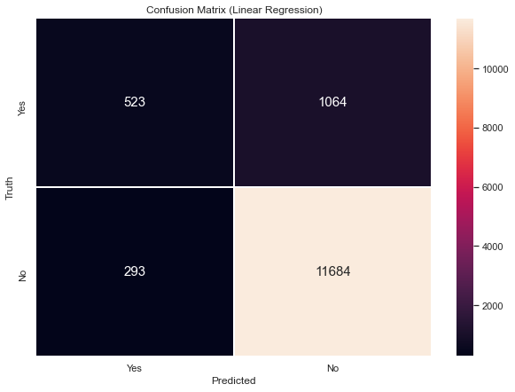

```python
# Draw confusion matrix
draw_confusion_matrix(lr_model, x_test, y_test, title='Confusion Matrix (Linear Regression)')
```

```python
# Get model performance
lr_model_perf = get_model_perf(lr_model, x_train, x_test, y_train, y_test)
lr_model_perf_df = pd.DataFrame(lr_model_perf, index=['Logistic Regression Performance metrics'])
lr_model_perf_df.T
```

|  | Logistic Regression Performance metrics |
| --- | --- |
| True Positives | 523.000 |
| True Negatives | 11684.000 |
| False Positives | 293.000 |
| False Negatives | 1064.000 |
| Train Accuracy | 90.230 |
| Test Accuracy | 89.996 |
| ROC AUC | 0.653 |
| Percision Score | 0.641 |
| Recall Score | 0.330 |
| F1-score | 0.690 |

#### *Observations*

- The logistic regression model with default parameters (solver=lbfgs and penalty=l2), seems to perform well on the train and test set.
- The false negatives (Type II errors) are fairly high impacting recall and the F1-score.
- False positives (Type I errors) are quite low.

### Decision Tree Model

```python
# Create decision tree instance, with gini impurity

# Inorder to avoid overfitting, let's control the depth of the tree to 6 levels.
dtree_model = DecisionTreeClassifier(random_state=RANDOM_STATE, criterion='gini', max_depth=6)
dtree_model.fit(x_train, y_train)
```

```
DecisionTreeClassifier(max_depth=6, random_state=42)
```

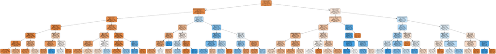

```python
# Draw Decision tree
# If the dot utility is not installed on the system, please comment out this line, to avoid any exceptions.
draw_tree(dtree_model, 'dtree_model.dot', 'dtree_model.png', ['No', 'Yes'], list(x_train))
```

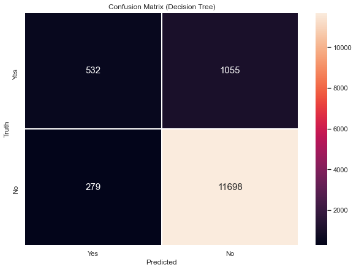

```python
# Draw confusion matrix for Decision Tree
draw_confusion_matrix(dtree_model, x_test, y_test, title='Confusion Matrix (Decision Tree)')
```

```python
# Get performance for decision tree
dt_model_perf = get_model_perf(dtree_model, x_train, x_test, y_train, y_test)
dt_model_perf_df = pd.DataFrame(dt_model_perf, index=['Decision Tree Performance'])
dt_model_perf_df.T
```

|  | Decision Tree Performance |
| --- | --- |
| True Positives | 532.000 |
| True Negatives | 11698.000 |
| False Positives | 279.000 |
| False Negatives | 1055.000 |
| Train Accuracy | 90.644 |
| Test Accuracy | 90.165 |
| ROC AUC | 0.656 |
| Percision Score | 0.656 |
| Recall Score | 0.335 |
| F1-score | 0.695 |

#### *Observations* :

- Decision Tree model performed better than logistic regression, yielding better train and test accuracies.
- It reduced false positives and false negatives, effectively improving precision and recall scores.
- Consequently the f1-score has improved too.
- The area under the curve (ROC AUC) has increased indicating better classification performance.

```python
# Let's look at the important features identified.
imp_feat_df = pd.DataFrame(dtree_model.feature_importances_, columns = ['Importance'], index=x_train.columns)
imp_feat_df[imp_feat_df.Importance > 0.001].sort_values(by='Importance', ascending=False)
```

|  | Importance |
| --- | --- |
| duration | 0.532753 |
| poutcome_success | 0.267083 |
| housing | 0.044602 |
| pdays | 0.038113 |
| age | 0.032070 |
| month_mar | 0.028232 |
| month_oct | 0.012795 |
| month_may | 0.006075 |
| marital_married | 0.006036 |
| balance | 0.005795 |
| campaign | 0.003748 |
| day_6 | 0.002894 |
| month_aug | 0.002363 |
| job_technician | 0.002334 |
| job_entrepreneur | 0.002216 |
| day_20 | 0.001866 |
| education_secondary | 0.001764 |
| month_nov | 0.001608 |
| job_services | 0.001512 |
| day_31 | 0.001369 |
| day_13 | 0.001332 |
| loan | 0.001264 |
| month_sep | 0.001178 |
| job_self-employed | 0.001000 |

### Ensemble Model using Bagging

```python
# Let's create bagging classifier with the decision tree model we have build prviously.
bgcl_model = BaggingClassifier(base_estimator=dtree_model, n_estimators=NUM_ESTIMATORS, random_state=RANDOM_STATE)
bgcl_model.fit(x_train, y_train)
```

```
BaggingClassifier(base_estimator=DecisionTreeClassifier(max_depth=6,
                                                        random_state=42),
                  n_estimators=50, random_state=42)
```

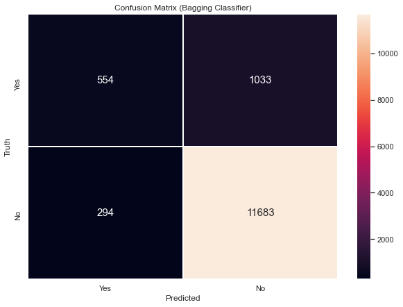

```python
# Draw confusion matrix for Bagging Classifier
draw_confusion_matrix(bgcl_model, x_test, y_test, title='Confusion Matrix (Bagging Classifier)')
```

```python
# Get performance for bagging classifier
bgcl_model_perf = get_model_perf(bgcl_model, x_train, x_test, y_train, y_test)
bgcl_model_perf_df = pd.DataFrame(bgcl_model_perf, index=['Bagging Classifier Performance'])
bgcl_model_perf_df.T
```

|  | Bagging Classifier Performance |
| --- | --- |
| True Positives | 554.000 |
| True Negatives | 11683.000 |
| False Positives | 294.000 |
| False Negatives | 1033.000 |
| Train Accuracy | 91.039 |
| Test Accuracy | 90.217 |
| ROC AUC | 0.662 |
| Percision Score | 0.653 |
| Recall Score | 0.349 |
| F1-score | 0.701 |

### *Observations* :

- Using Bagging with Decision Tree, we see slight improvement in recall.
- The train and test accuracies have also improved slightly.
- Also there is slight improvement in the F1 score along with ROC AUC, indicating better classification capability.

### Ensemble Model using Random Forest

```python
# Create instance of random forest classifier
rnd_clf_model = RandomForestClassifier(n_estimators=NUM_ESTIMATORS, max_features=25, random_state=RANDOM_STATE)
rnd_clf_model.fit(x_train, y_train)
```

```
RandomForestClassifier(max_features=25, n_estimators=50, random_state=42)
```

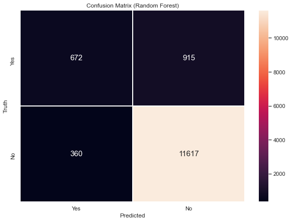

```python
# Draw confusion matrix for Random Forest
draw_confusion_matrix(rnd_clf_model, x_test, y_test, title='Confusion Matrix (Random Forest)')
```

```python
# Get performance for random forest classifier
rnd_clf_model_perf = get_model_perf(rnd_clf_model, x_train, x_test, y_train, y_test)
rnd_clf_model_perf_df = pd.DataFrame(rnd_clf_model_perf, index=['Random Forest Classifier Performance'])
rnd_clf_model_perf_df.T
```

|  | Random Forest Classifier Performance |
| --- | --- |
| True Positives | 672.000 |
| True Negatives | 11617.000 |
| False Positives | 360.000 |
| False Negatives | 915.000 |
| Train Accuracy | 99.962 |
| Test Accuracy | 90.600 |
| ROC AUC | 0.697 |
| Percision Score | 0.651 |
| Recall Score | 0.423 |
| F1-score | 0.731 |

### Ensemble Model using Adaptive Boosting

```python
abcl_model = AdaBoostClassifier(n_estimators=NUM_ESTIMATORS, random_state=RANDOM_STATE)
abcl_model.fit(x_train, y_train)
```

```
AdaBoostClassifier(random_state=42)
```

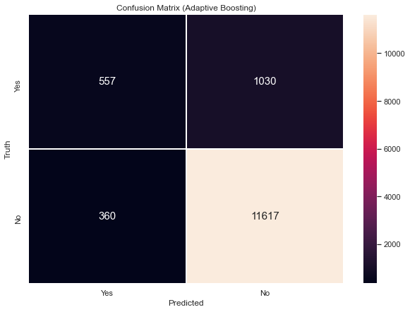

```python
# Draw confusion matrix for Adaptive Boosting
draw_confusion_matrix(abcl_model, x_test, y_test, title='Confusion Matrix (Adaptive Boosting)')
```

```python
# Get performance with adaptive boosting
abcl_model_perf = get_model_perf(abcl_model, x_train, x_test, y_train, y_test)
abcl_model_perf_df = pd.DataFrame(abcl_model_perf, index=['Adaptive Boosting Classifier Performance'])
abcl_model_perf_df.T
```

|  | Adaptive Boosting Classifier Performance |
| --- | --- |
| True Positives | 557.000 |
| True Negatives | 11617.000 |
| False Positives | 360.000 |
| False Negatives | 1030.000 |
| Train Accuracy | 90.050 |
| Test Accuracy | 89.752 |
| ROC AUC | 0.660 |
| Percision Score | 0.607 |
| Recall Score | 0.351 |
| F1-score | 0.694 |

#### *Observations* :

- Adaptive Boosting yielded good classification performance, but not as good as Random Forest.
- The train and test accuracies are nearly the same as other models (except Random Forest).
- ROC and AUC along with F1-score has not impoved over Random Forest, indicating lower classification performance.

### Ensemble Model using Gradient Boosting

```python
gbcl_model = GradientBoostingClassifier(n_estimators=NUM_ESTIMATORS, random_state=RANDOM_STATE)
gbcl_model.fit(x_train, y_train)
```

```
GradientBoostingClassifier(n_estimators=50, random_state=42)
```

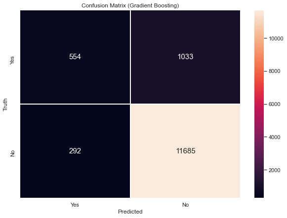

```python
# Draw confusion matrix for Gradient Boosting
draw_confusion_matrix(gbcl_model, x_test, y_test, title='Confusion Matrix (Gradient Boosting)')
```

```python
# Get performance with adaptive boosting
gbcl_model_perf = get_model_perf(gbcl_model, x_train, x_test, y_train, y_test)
gbcl_model_perf_df = pd.DataFrame(gbcl_model_perf, index=['Gradient Boosting Classifier Performance'])
gbcl_model_perf_df.T
```

|  | Gradient Boosting Classifier Performance |
| --- | --- |
| True Positives | 554.000 |
| True Negatives | 11685.000 |
| False Positives | 292.000 |
| False Negatives | 1033.000 |
| Train Accuracy | 90.641 |
| Test Accuracy | 90.231 |
| ROC AUC | 0.662 |
| Percision Score | 0.655 |
| Recall Score | 0.349 |
| F1-score | 0.701 |

#### *Observations* :

- Gradient Boosting performed a bit better than Adaptive boosting.
- Train and test accuracies are slightly better.
- Precision score has improved over adaptive boosting, resulting in slightly better F1-score.

### Comparing All Models

```python
# Merge perfrormance numbers of all models created so far
merged_perf_dict = {}
all_model_names = ['Logistic Regression', 'Decision Tree', 'Bagging', 'Random Forest', 'Ada. Boost', 'Gradient Boost']
all_model_perf = [lr_model_perf, dt_model_perf, bgcl_model_perf, rnd_clf_model_perf, abcl_model_perf, gbcl_model_perf]

for key in lr_model_perf.keys():
    merged_perf_dict[key] = [x[key] for x in all_model_perf]

merged_perf_df = pd.DataFrame(merged_perf_dict, index=all_model_names)
merged_perf_df.T
```

|  | Logistic Regression | Decision Tree | Bagging | Random Forest | Ada. Boost | Gradient Boost |
| --- | --- | --- | --- | --- | --- | --- |
| True Positives | 523.000 | 532.000 | 554.000 | 672.000 | 557.000 | 554.000 |
| True Negatives | 11684.000 | 11698.000 | 11683.000 | 11617.000 | 11617.000 | 11685.000 |
| False Positives | 293.000 | 279.000 | 294.000 | 360.000 | 360.000 | 292.000 |
| False Negatives | 1064.000 | 1055.000 | 1033.000 | 915.000 | 1030.000 | 1033.000 |
| Train Accuracy | 90.230 | 90.644 | 91.039 | 99.962 | 90.050 | 90.641 |
| Test Accuracy | 89.996 | 90.165 | 90.217 | 90.600 | 89.752 | 90.231 |
| ROC AUC | 0.653 | 0.656 | 0.662 | 0.697 | 0.660 | 0.662 |
| Percision Score | 0.641 | 0.656 | 0.653 | 0.651 | 0.607 | 0.655 |
| Recall Score | 0.330 | 0.335 | 0.349 | 0.423 | 0.351 | 0.349 |
| F1-score | 0.690 | 0.695 | 0.701 | 0.731 | 0.694 | 0.701 |

#### *Observations and reasoning for the best algorithm*:

Based on above table of metrics, Random Forest demonstrates the best classification performance. RandomForest is an ensemble of decision trees, generally trained via bagging method, typically with max_samples set to the size of the training set. Ideally, the BaggingClassifier with decision tree should perform equally well as RandomForestClassifier.

However, the RandomForestClassifer is more optimized for Decision Trees. It introduces extra randomness by selecting subset of variables randomly when growing trees, instead of searching for the very best feature when splitting a node. Thus, the algorithm results in greater tree diversity. This results in higher bias for a lower variance, generally yielding an overall better model. The Random Forest has best train and test accuracies along with best ROC AUC. It also has the best F1-score, indicating best weighted average of precision and recall scores. Mainly, the model has the least False Negatives (Type II errors).

Logistic Regression has the lowest classification performance, as it has the lowest ROC AUC. Although Decision Tree has lower recall score, it has the best precision score and least False Positives (Type I errors). Almost all the models performed equally well as the features were already scaled. Feature scaling helped improve performance of all models and is an essential step in the data analysis.

## Conclusion

The goal is to help the marketing team identify potential customers who are relatively more likely to subscribe to term deposit and thus increase their hit ratio.

For the given business use case, the cost of Type II errors (False Negatives) is significant. Type II errors will result in decreased hit ratio implying losing potential customers for term deposit. For this reason, Random Forest model would be a good candidate model, as it has the lowest False Negatives with highest recall score.

If the marketing team intends to focus more on the cost of marketing per customer, then the Decision Tree model would be a good candidate, as it has lowest Type I errors (False positives).

**Thoughts on further model improvements**: The amount of unknowns in the dataset for various attributes must be minimized by collecting more data wherever necessary. Especially, the outcome of the previous campaign (poutcome). Additional data such as geographical location, salaries, gender, credit scores, etc. related to customers, can be added for better understanding the outcome.